# Elsevier 2022 SDG mapping

# General to all SDGs

## Introduction

The United Nations Sustainable Development Goals (SDGs) challenge the global community to build a world where no one is left behind.

Since 2018, Elsevier has generated SDG search queries to help researchers and institutions track and demonstrate progress toward the SDG targets. In the past 3 years, these queries, along with the university’s own data and evidence supporting progress and contributions to the particular SDG outside of research-based metrics, are used for the THE Impact Rankings.

## Method

For 2022, this SDG uses the exact same search query and ML algorithm as the Elsevier 2021 SDG mapping. [Full details of the 2021 methodology are available on Digital Commons Data.](https://elsevier.digitalcommonsdata.com/datasets/9sxdykm8s4/4)

# [SDG 5 - Achieve gender equality and empower all women and girls](https://sdgs.un.org/goals/goal5)

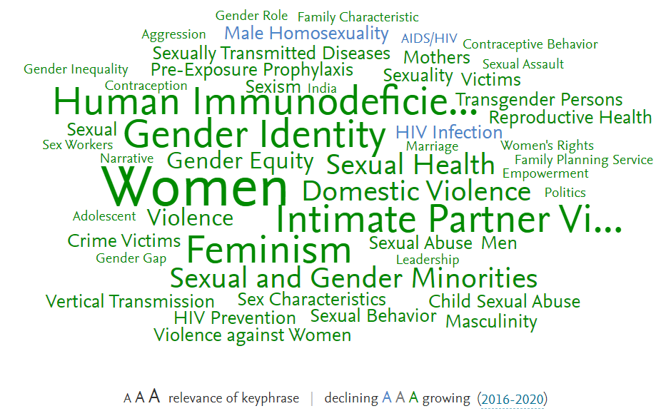

Explore this wordcloud plus the most active contributors on the [SciVal SDG site](https://scival.com/sdg)

## Query

Below is the full search query used for this SDG. We’ve broken it down by each query component. Use the + and – to concatenate the different bracket levels.

(

(

(

(

(TITLE("technology") OR TITLE("technologies") OR TITLE("ICT")) AND (TITLE("gender") OR TITLE("women"))

)

OR

(

(AUTHKEY("technology") OR AUTHKEY("technologies") OR AUTHKEY("ICT")) AND (AUTHKEY("gender") OR AUTHKEY("women"))

)

OR TITLE-ABS

(

"Women in ICT"

)

OR AUTHKEY

(

"Women in ICT"

)

OR

(

(TITLE-ABS("gender gap") OR TITLE-ABS("gender* inequ*") OR TITLE-ABS("gender* equ*")) AND (TITLE-ABS("mobile phone") OR TITLE-ABS("cell phone") OR TITLE-ABS("cellular phone") OR TITLE-ABS("mobile device"))

)

OR

(

(AUTHKEY("gender gap") OR AUTHKEY("gender* inequ*") OR AUTHKEY("gender* equ*")) AND (AUTHKEY("mobile phone") OR AUTHKEY("cell phone") OR AUTHKEY("cellular phone") OR AUTHKEY("mobile device"))

)

OR

(

TITLE-ABS("women") AND TITLE-ABS("perseverance") AND (TITLE-ABS("science, technology") OR TITLE-ABS("information and communication technologies"))

)

OR

(

AUTHKEY("women") AND AUTHKEY("perseverance") AND (AUTHKEY("science, technology") OR AUTHKEY("information and communication technologies"))

)

OR

(

TITLE-ABS("women") AND TITLE-ABS("technology") AND TITLE-ABS("empowerment")

)

OR

(

AUTHKEY("women") AND AUTHKEY("technology") AND AUTHKEY("empowerment")

)

OR

(

TITLE-ABS("ict access") AND (TITLE-ABS("women") OR TITLE-ABS("gender"))

)

OR

(

AUTHKEY("ict access") AND (AUTHKEY("women") OR AUTHKEY("gender"))

)

OR

(

(TITLE-ABS("user-technology") AND (TITLE-ABS("women") OR TITLE-ABS("gender"))) OR (TITLE-ABS("usertechnology") AND (TITLE-ABS("women") OR TITLE-ABS("gender")))

)

OR

(

(AUTHKEY("user-technology") AND (AUTHKEY("women") OR AUTHKEY("gender"))) OR (AUTHKEY("usertechnology") AND (AUTHKEY("women") OR AUTHKEY("gender")))

)

OR

(

TITLE-ABS("Technology acceptance") AND (TITLE-ABS("women") OR TITLE-ABS("gender"))

)

OR

(

AUTHKEY("Technology acceptance") AND (AUTHKEY("women") OR AUTHKEY("gender"))

)

OR

(

TITLE-ABS("exclusion of women ") AND TITLE-ABS("technoscience")

)

OR

(

AUTHKEY("exclusion of women ") AND AUTHKEY("technoscience")

)

OR

(

(TITLE-ABS("ict use") OR TITLE-ABS("use of ict")) AND (TITLE-ABS("women") OR TITLE-ABS("gender"))

)

OR

(

(AUTHKEY("ict use") OR AUTHKEY("use of ict")) AND (AUTHKEY("women") OR AUTHKEY("gender"))

)

OR

(

TITLE-ABS("gender") AND TITLE-ABS("information and communication technologies") AND TITLE-ABS("technology use")

)

OR

(

AUTHKEY("gender") AND AUTHKEY("information and communication technologies") AND AUTHKEY("technology use")

)

OR TITLE-ABS

(

"decline of women in technology disciplines"

)

OR AUTHKEY

(

"decline of women in technology disciplines"

)

OR

(

TITLE-ABS("women") AND (TITLE-ABS("IT* enrollment*") OR TITLE-ABS("IT* enrolment*"))

)

OR

(

AUTHKEY("women") AND (AUTHKEY("IT* enrollment*") OR AUTHKEY("IT* enrolment*"))

)

OR

(

TITLE-ABS("women") AND (TITLE-ABS("mobile phone") OR TITLE-ABS("cell phone") OR TITLE-ABS("cellular phone") OR TITLE-ABS("mobile device")) AND (TITLE-ABS("owning") OR TITLE-ABS("ownership"))

)

OR

(

AUTHKEY("women") AND (AUTHKEY("mobile phone") OR AUTHKEY("cell phone") OR AUTHKEY("cellular phone") OR AUTHKEY("mobile device")) AND (AUTHKEY("owning") OR AUTHKEY("ownership"))

)

OR

(

TITLE-ABS("Technological preparedness ") AND (TITLE-ABS("women") OR TITLE-ABS("gender"))

)

OR

(

AUTHKEY("Technological preparedness ") AND (AUTHKEY("women") OR AUTHKEY("gender"))

)

OR

(

TITLE-ABS("ICT* education*") AND (TITLE-ABS("women") OR TITLE-ABS("gender"))

)

OR

(

AUTHKEY("ICT* education*") AND (AUTHKEY("women") OR AUTHKEY("gender"))

)

OR

(

TITLE-ABS("women") AND (TITLE-ABS("use of mobile phone") OR TITLE-ABS("use of cellphone") OR TITLE-ABS("use of mobile device")) AND (TITLE-ABS("barriers") OR TITLE-ABS("ICT usage") OR TITLE-ABS("promot*"))

)

OR

(

AUTHKEY("women") AND (AUTHKEY("use of mobile phone") OR AUTHKEY("use of cellphone") OR AUTHKEY("use of mobile device")) AND (AUTHKEY("barriers") OR AUTHKEY("ICT usage") OR AUTHKEY("promot*"))

)

OR

(

TITLE-ABS("gender gap") AND TITLE-ABS("technolog*")

)

OR

(

AUTHKEY("gender gap") AND AUTHKEY("technolog*")

)

OR

(

TITLE-ABS("gender") AND TITLE-ABS("information and communication technologies") AND TITLE-ABS("promot*")

)

OR

(

AUTHKEY("gender") AND AUTHKEY("information and communication technologies") AND AUTHKEY("promot*")

)

OR

(

TITLE-ABS("Educational* practice* ") AND TITLE-ABS("gender") AND (TITLE-ABS("technology use") OR TITLE-ABS("ICTs") OR TITLE-ABS("information and communication technologies"))

)

OR

(

AUTHKEY("Educational* practice* ") AND AUTHKEY("gender") AND (AUTHKEY("technology use") OR AUTHKEY("ICTs") OR AUTHKEY("information and communication technologies"))

)

OR

(

TITLE-ABS("women in computer science") OR TITLE-ABS("women in computer sciences")

)

OR

(

AUTHKEY("women in computer science") OR AUTHKEY("women in computer sciences")

)

OR

(

TITLE-ABS("women") AND TITLE-ABS("internet access")

)

OR

(

AUTHKEY("women") AND AUTHKEY("internet access")

)

OR

(

TITLE-ABS("women in computing") OR TITLE-ABS("women in stem")

)

OR

(

AUTHKEY("women in computing") OR AUTHKEY("women in stem")

)

OR

(

TITLE-ABS("Women''s* interest*") AND TITLE-ABS("in* technolog*")

)

OR

(

AUTHKEY("Women''s* interest*") AND AUTHKEY("in* technolog*")

)

OR

(

(TITLE-ABS("Perceived ease of use") OR TITLE-ABS("perceived usefulness")) AND TITLE-ABS("technolog*") AND (TITLE-ABS("women") OR TITLE-ABS("gender"))

)

OR

(

(AUTHKEY("Perceived ease of use") OR AUTHKEY("perceived usefulness")) AND AUTHKEY("technolog*") AND (AUTHKEY("women") OR AUTHKEY("gender"))

)

OR

(

TITLE-ABS("Empowering") AND TITLE-ABS("women") AND (TITLE-ABS("technology") OR TITLE-ABS("technologies"))

)

OR

(

AUTHKEY("Empowering") AND AUTHKEY("women") AND (AUTHKEY("technology") OR AUTHKEY("technologies"))

)

OR

(

((TITLE-ABS("under*-represent*") OR TITLE-ABS("under* represent*")) AND TITLE-ABS("women") AND (TITLE-ABS("information* science*") OR TITLE-ABS("technolog*") OR TITLE-ABS("communication* science*") OR TITLE-ABS("ict"))) OR ((TITLE-ABS("underrepresent*") OR TITLE-ABS("under* represent*")) AND TITLE-ABS("women") AND (TITLE-ABS("information* science*") OR TITLE-ABS("technolog*") OR TITLE-ABS("communication* science*") OR TITLE-ABS("ict")))

)

OR

(

((AUTHKEY("under*-represent*") OR AUTHKEY("under* represent*")) AND AUTHKEY("women") AND (AUTHKEY("information* science*") OR AUTHKEY("technolog*") OR AUTHKEY("communication* science*") OR AUTHKEY("ict"))) OR ((AUTHKEY("underrepresent*") OR AUTHKEY("under* represent*")) AND AUTHKEY("women") AND (AUTHKEY("information* science*") OR AUTHKEY("technolog*") OR AUTHKEY("communication* science*") OR AUTHKEY("ict")))

)

OR

(

TITLE-ABS("use* of* information* system*") AND (TITLE-ABS("women") OR TITLE-ABS("gender"))

)

OR

(

AUTHKEY("use* of* information* system*") AND (AUTHKEY("women") OR AUTHKEY("gender"))

)

OR TITLE-ABS

(

"Women in information sciences"

)

OR AUTHKEY

(

"Women in information sciences"

)

OR

(

((TITLE-ABS("Under*-represent*") OR TITLE-ABS("under* represent*")) AND TITLE-ABS("women") AND (TITLE-ABS("computer science") OR TITLE-ABS("computing science"))) OR ((TITLE-ABS("Underrepresent*") OR TITLE-ABS("under* represent*")) AND TITLE-ABS("women") AND (TITLE-ABS("computer science") OR TITLE-ABS("computing science")))

)

OR

(

((AUTHKEY("Under*-represent*") OR AUTHKEY("under* represent*")) AND AUTHKEY("women") AND (AUTHKEY("computer science") OR AUTHKEY("computing science"))) OR ((AUTHKEY("Underrepresent*") OR AUTHKEY("under* represent*")) AND AUTHKEY("women") AND (AUTHKEY("computer science") OR AUTHKEY("computing science")))

)

OR

(

TITLE-ABS("Barrier*") AND TITLE-ABS("women") AND (TITLE-ABS("ICTs") OR TITLE-ABS("information and communication technologies") OR TITLE-ABS("information science") OR TITLE-ABS("computer science") OR TITLE-ABS("computing science")) AND TITLE-ABS("career*")

)

OR

(

AUTHKEY("Barrier*") AND AUTHKEY("women") AND (AUTHKEY("ICTs") OR AUTHKEY("information and communication technologies") OR AUTHKEY("information science") OR AUTHKEY("computer science") OR AUTHKEY("computing science")) AND AUTHKEY("career*")

)

OR

(

TITLE-ABS("women") AND TITLE-ABS("information and communication technologies") AND (TITLE-ABS("empowerment") OR TITLE-ABS("empowering"))

)

OR

(

AUTHKEY("women") AND AUTHKEY("information and communication technologies") AND (AUTHKEY("empowerment") OR AUTHKEY("empowering"))

)

OR

(

TITLE-ABS("gender* divide*") AND (TITLE-ABS("information* science*") OR TITLE-ABS("technolog*") OR TITLE-ABS("communication* science*") OR TITLE-ABS("ICTs") OR TITLE-ABS("computer science") OR TITLE-ABS("computing science"))

)

OR

(

AUTHKEY("gender* divide*") AND (AUTHKEY("information* science*") OR AUTHKEY("technolog*") OR AUTHKEY("communication* science*") OR AUTHKEY("ICTs") OR AUTHKEY("computer science") OR AUTHKEY("computing science"))

)

OR

(

TITLE-ABS("Educational technology") AND (TITLE-ABS("gender") OR TITLE-ABS("women") OR TITLE-ABS("woman") OR TITLE-ABS("girl*"))

)

OR

(

AUTHKEY("Educational technology") AND (AUTHKEY("gender") OR AUTHKEY("women") OR AUTHKEY("woman") OR AUTHKEY("girl*"))

)

OR

(

TITLE-ABS("women") AND TITLE-ABS("enabling technologies") AND (TITLE-ABS("engagement") OR TITLE-ABS("promot*"))

)

OR

(

AUTHKEY("women") AND AUTHKEY("enabling technologies") AND (AUTHKEY("engagement") OR AUTHKEY("promot*"))

)

OR TITLE-ABS

(

"representation of women in science, technology, engineering"

)

OR AUTHKEY

(

"representation of women in science, technology, engineering"

)

OR TITLE-ABS

(

"stem women"

)

OR AUTHKEY

(

"stem women"

)

OR

(

TITLE-ABS("retention of women") AND (TITLE-ABS("computer science") OR TITLE-ABS("information and communication technologies"))

)

OR

(

AUTHKEY("retention of women") AND (AUTHKEY("computer science") OR AUTHKEY("information and communication technologies"))

)

OR

(

TITLE-ABS("Digital divide") AND (TITLE-ABS("women") OR TITLE-ABS("gender"))

)

OR

(

AUTHKEY("Digital divide") AND (AUTHKEY("women") OR AUTHKEY("gender"))

)

OR

(

TITLE-ABS("decline of women") AND (TITLE-ABS("technology disciplines") OR TITLE-ABS("IT fields"))

)

OR

(

AUTHKEY("decline of women") AND (AUTHKEY("technology disciplines") OR AUTHKEY("IT fields"))

)

OR

(

TITLE-ABS("use* of* new* technolog*") AND (TITLE-ABS("differenc*") OR TITLE-ABS("variation*")) AND (TITLE-ABS("women") OR TITLE-ABS("gender"))

)

OR

(

AUTHKEY("use* of* new* technolog*") AND (AUTHKEY("differenc*") OR AUTHKEY("variation*")) AND (AUTHKEY("women") OR AUTHKEY("gender"))

)

OR

(

TITLE-ABS("Gender") AND TITLE-ABS("in ICT")

)

OR

(

AUTHKEY("Gender") AND AUTHKEY("in ICT")

)

OR

(

TITLE-ABS("icts") AND TITLE-ABS("gender") AND (TITLE-ABS("barrier*") OR TITLE-ABS("empower*"))

)

OR

(

AUTHKEY("icts") AND AUTHKEY("gender") AND (AUTHKEY("barrier*") OR AUTHKEY("empower*"))

)

OR

(

TITLE-ABS("women") AND (TITLE-ABS("mobile phone") OR TITLE-ABS("cell phone") OR TITLE-ABS("cellular phone") OR TITLE-ABS("mobile device")) AND (TITLE-ABS("access") OR TITLE-ABS("accessibility"))

)

OR

(

AUTHKEY("women") AND (AUTHKEY("mobile phone") OR AUTHKEY("cell phone") OR AUTHKEY("cellular phone") OR AUTHKEY("mobile device")) AND (AUTHKEY("access") OR AUTHKEY("accessibility"))

)

OR

(

TITLE-ABS("More women") AND (TITLE-ABS("information science") OR TITLE-ABS("ICTs") OR TITLE-ABS("communication science") OR TITLE-ABS("computer science") OR TITLE-ABS("computing science") OR TITLE-ABS("information and communication technologies"))

)

OR

(

AUTHKEY("More women") AND (AUTHKEY("information science") OR AUTHKEY("ICTs") OR AUTHKEY("communication science") OR AUTHKEY("computer science") OR AUTHKEY("computing science") OR AUTHKEY("information and communication technologies"))

)

)

AND NOT

(

(